# Explaining Parameters

Jonas Petter

3/24/2022

## Parameters Overview

### Current Parameters

- **emo_intensity**: Property of a stimulus and of the agent’s state. Scale from 0 to 10.
- **N_RUNS**: Number of time points the simulation has overall.
- **N_STIMULI**: Number of uniquely identifiable stimuli that will be generated.
- **N_ACTIONS**: Number of actions available for the agent.
- **alpha**: The learning rate, i.e. how much is the new information weighted compared to all previous information.
- **gamma**: The discount factor for future rewards.
- **epsilon**: The probability to pick a random action, instead of the optimal one.
- **engage_delay**: The time point at which adaptation takes places when using engagement. This can be max = 3.
- **engage_adaptation**: The amount by which the emotion is reduced permanently through engagement.
- **engage_benefit**: The amount by which the emotion is reduced temporarily through engagement.
- **disengage_benefit**: The amount by which the emotion is reduced temporarily through disengagement.
- **seed**: The random seed to reproduce output.

### Other Possible Parameters

These things are currently hard-coded, but we might want to consider making them parameters that are easily changed.

- **Stimulus Length**: Currently, a new stimulus is selected after every 3 time points. We could increase this if we want to model the intensity curve in more detail.
- **Action Selection Frequency**: Currently, the agent selects a new action only when a new stimulus is encountered. It sticks with this action until the stimulus is changed. It would be possible to make the agent chose an action more often e.g., at every time point.
- **Stimulus Generation**: Currently, a few stimuli are hard-coded and reused with different IDs. We might want to create a parameter instead to define allowed ranges of intensity.

## How to Run Simulations

1. Open `src/run_training.py`
2. Change `simulationValues` to the values the parameter should take. For example, if you want `Seed` to take values 1 to 8, this would be `simulationValues = [1, 2, 3, 4, 5, 6, 7, 8]` (or any function that creates this vector, such as `np.arange, 1, 9, 1)`). The values will be assigned to `Seed` in step 4. The vector can have any length, but even numbers produce nicer matrix plots.

If you don’t want to run any experiment, but directly look at the output, set `simulationValues = [1]`. Also note that there are plots at the bottom of the script, which are commented out `#plt.show()`. You probably want to activate those if not running simulation experiments.

3. Set the `file_name` to whatever parameter you are manipulating. For example `file_name = "Seed"`. Note that this creates a folder with the same name in `datasets`, so if the folder `Seed` already exists, name it `Seed_A`. **DONT USE NUMBERS IN THE FILE NAMES.**
4. Set only the parameter you want to simulate different values for to `sv`. For example:

```r
    N_RUNS = 10000
    N_STIMULI = 2000
    N_ACTIONS = 3

    alpha = .001
    gamma = .99
    epsilon = .1

    engage_delay = 2
    engage_benefit = 4
    disengage_benefit = 5
    engage_adaptation = 2
    seed = sv
```

5. Run the program. This will create datasets.
6. To get the output plots, open `analysis_scripts/plot_parameter.R`.
7. Scroll down and change `path` to where the datasets were stored that you just created. For example, `path <- "../datasets/Seed/"`
8. Change `parameterNames` to something descriptive. This will only affect the titles and file names of the plots, so probably the name of the parameter you changed. For example: `parameterName <- "Seed"`
9. Run the whole script and find the plots in the `plots` folder.

## Plots explanation

### Actions Plot

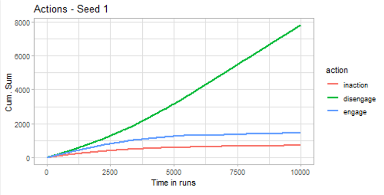

This plot shows the cumulative sum of actions the agent chose on the y-axis, across time points on the x-axis.

### Trajectories Plot

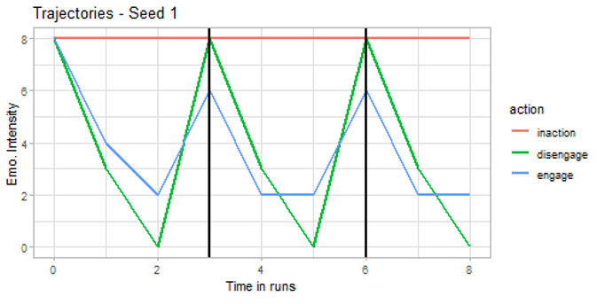

This plot shows how the individual actions affect an example emotion with intensity 8, across 3 iterations (3 x 3 time points). Emotion intensity is on the y-axis and time points are on the x-axis.

### Rewards Plot

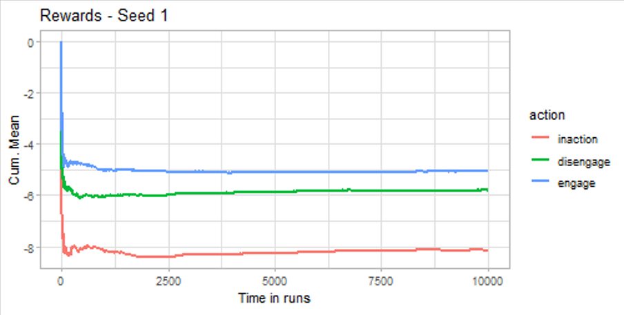

This plot shows how the mean reward received for each action develops across time. The cumulative mean is on the y-axis and time points are on the x-axis.

## Parameters in Detail

### Seed

This is to test the model is stable. The seed should generally not have an influence on the results, assuming there are no extremely weird seeds in which e.g., always a random action gets picked due to epsilon.

#### Parameter

```r
N_RUNS = 10000
N_STIMULI = 2000
N_ACTIONS = 3

alpha = .001
gamma = .99
epsilon = .1

engage_delay = 2
engage_benefit = 4
disengage_benefit = 5
engage_adaptation = 2
seed = 1:8
```

#### Plots

##### Actions

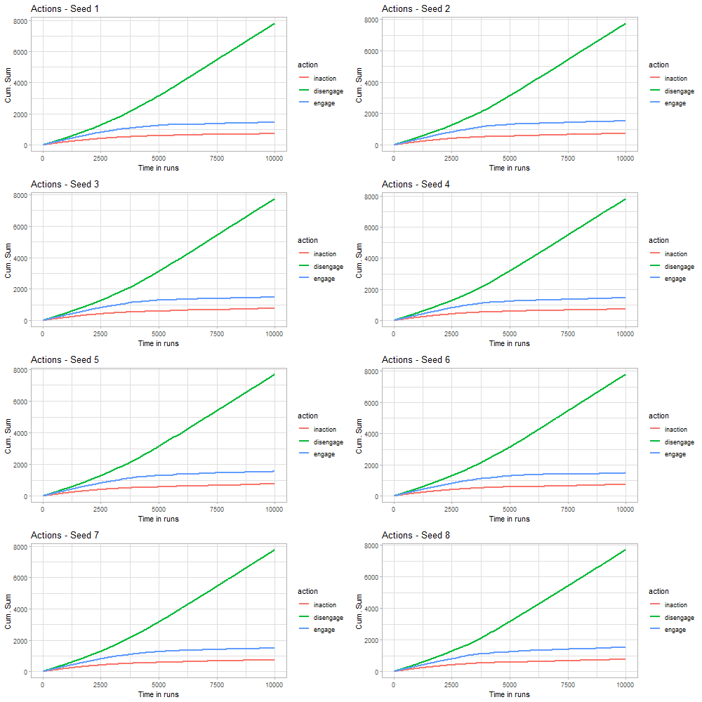

##### Trajectories

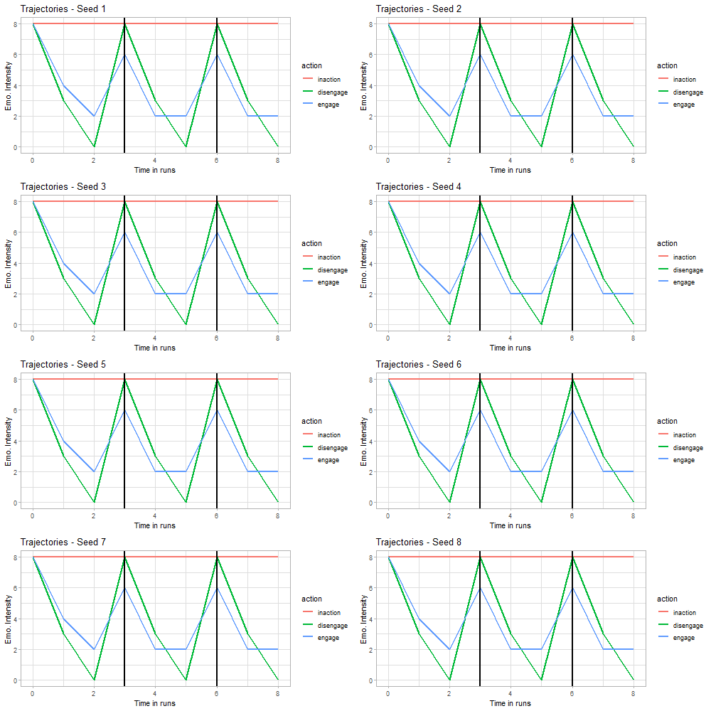

##### Rewards

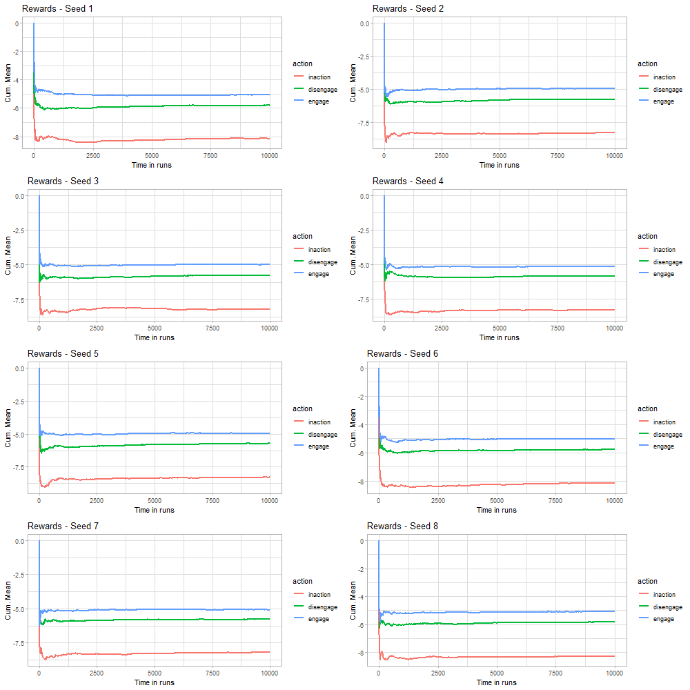

### N_RUNS

This can be used to show that the actions approach a certain value and do not change anymore at a later point. It could also be used to change the ratio of stimuli to runs, but this is probably easier done by manipulating `N_STIMULI`.

#### Parameter

```r
N_RUNS = [1000, 3000, 5000, 7000, 10000, 15000, 20000, 30000]
N_STIMULI = 2000
N_ACTIONS = 3

alpha = .001
gamma = .99
epsilon = .1

engage_delay = 2
engage_benefit = 4
disengage_benefit = 5
engage_adaptation = 2
seed = 123
```

#### Plots

##### Actions

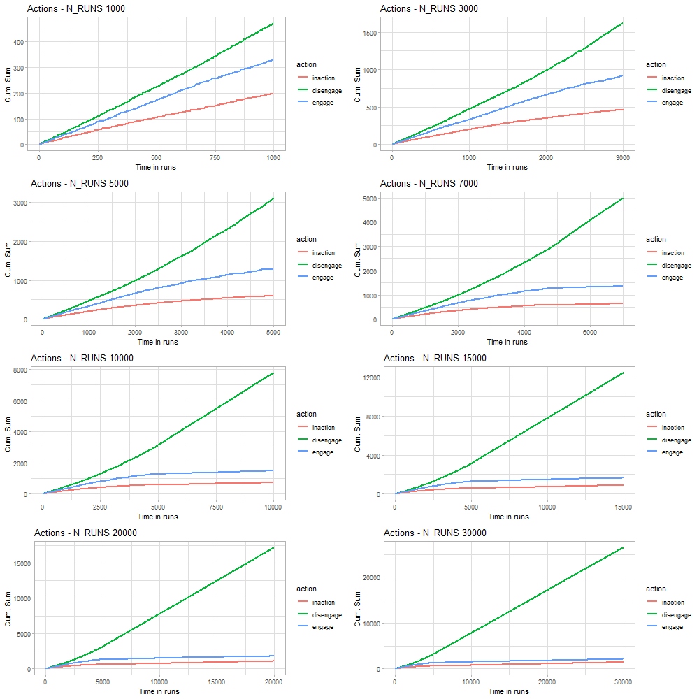

##### Trajectories

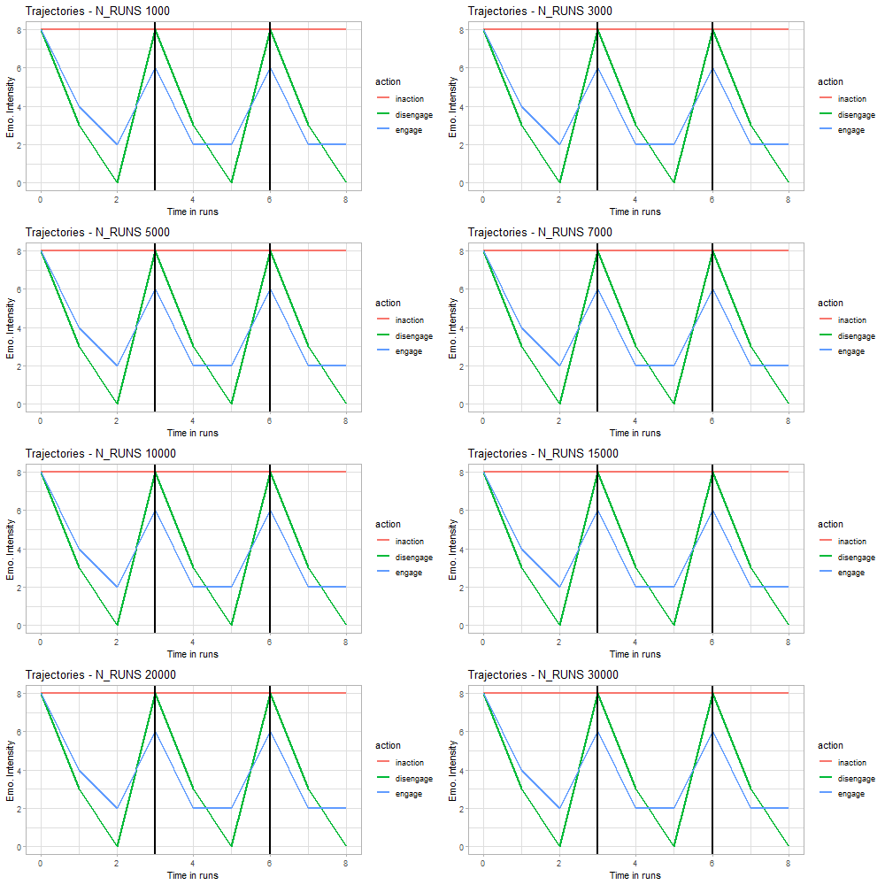

##### Rewards

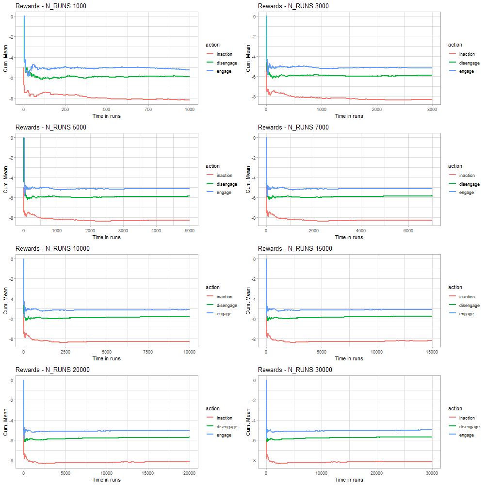

### N_STIMULI

This can be used to change how many unique stimuli there are in the environment. As currently all stimuli are equally likely to encounter, this also changes the probability to re-encounter a stimulus. Some individuals might have many different stimuli in their life, others might always encounter the same stimuli.

#### Parameter

```r
N_RUNS = 10000
N_STIMULI = [50, 100, 250, 500, 1000, 2000, 4000, 8000, 15000]
N_ACTIONS = 3

alpha = .001
gamma = .99
epsilon = .1

engage_delay = 2
engage_benefit = 4
disengage_benefit = 5
engage_adaptation = 2
seed = 123
```

#### Plots

##### Actions

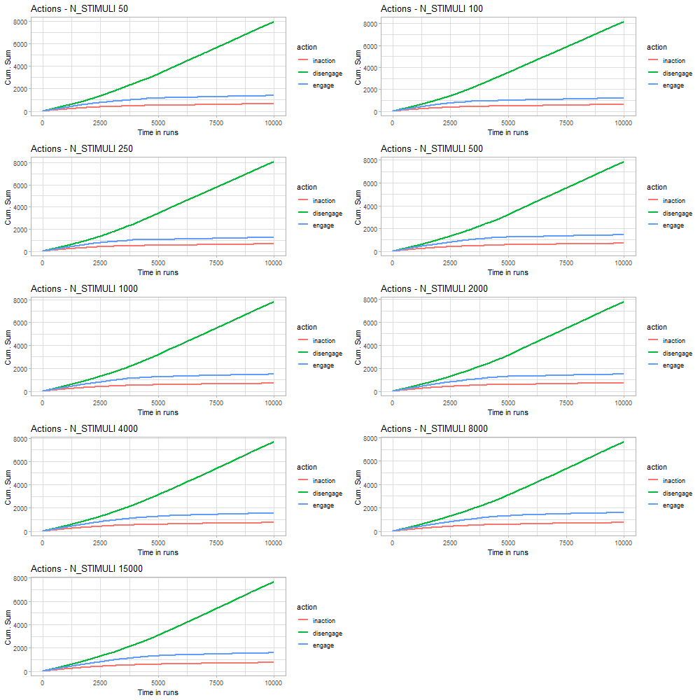

##### Trajectories

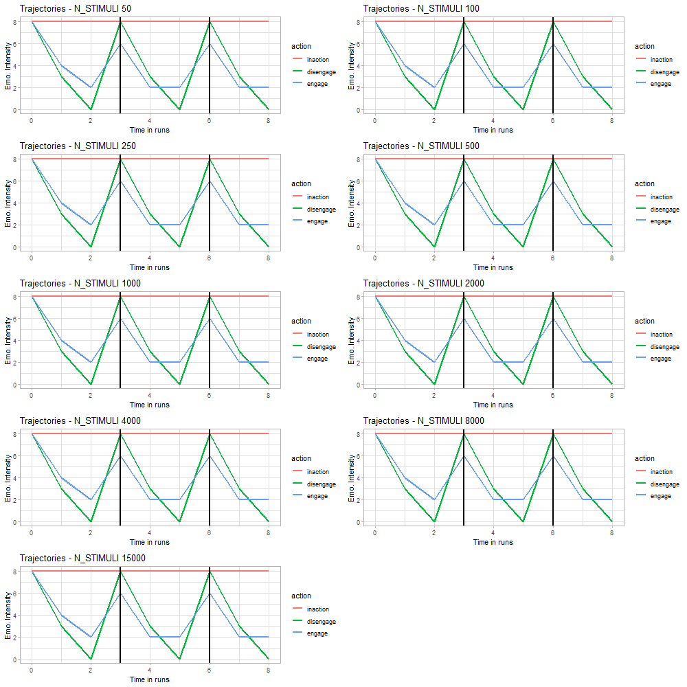

##### Rewards

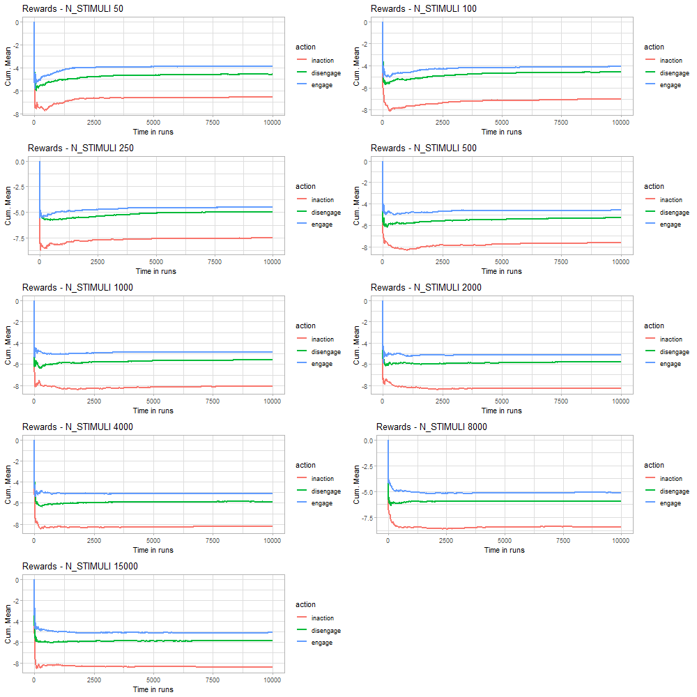

### alpha

This can be used to change how much the agent values new information compared to old information. This could for example represent people that are more likely to jump to conclusions vs people who are very slow to adapt their behavior?

#### Parameter

```r
N_RUNS = 10000
N_STIMULI = 2000
N_ACTIONS = 3

alpha = [0.001, 0.002, 0.004, 0.008, 0.016, 0.04, 0.08, 0.16, 0.33, 0.66, 0.99]
gamma = .99
epsilon = .1

engage_delay = 2
engage_benefit = 4
disengage_benefit = 5
engage_adaptation = 2
seed = 123
```

#### Plots

##### Actions

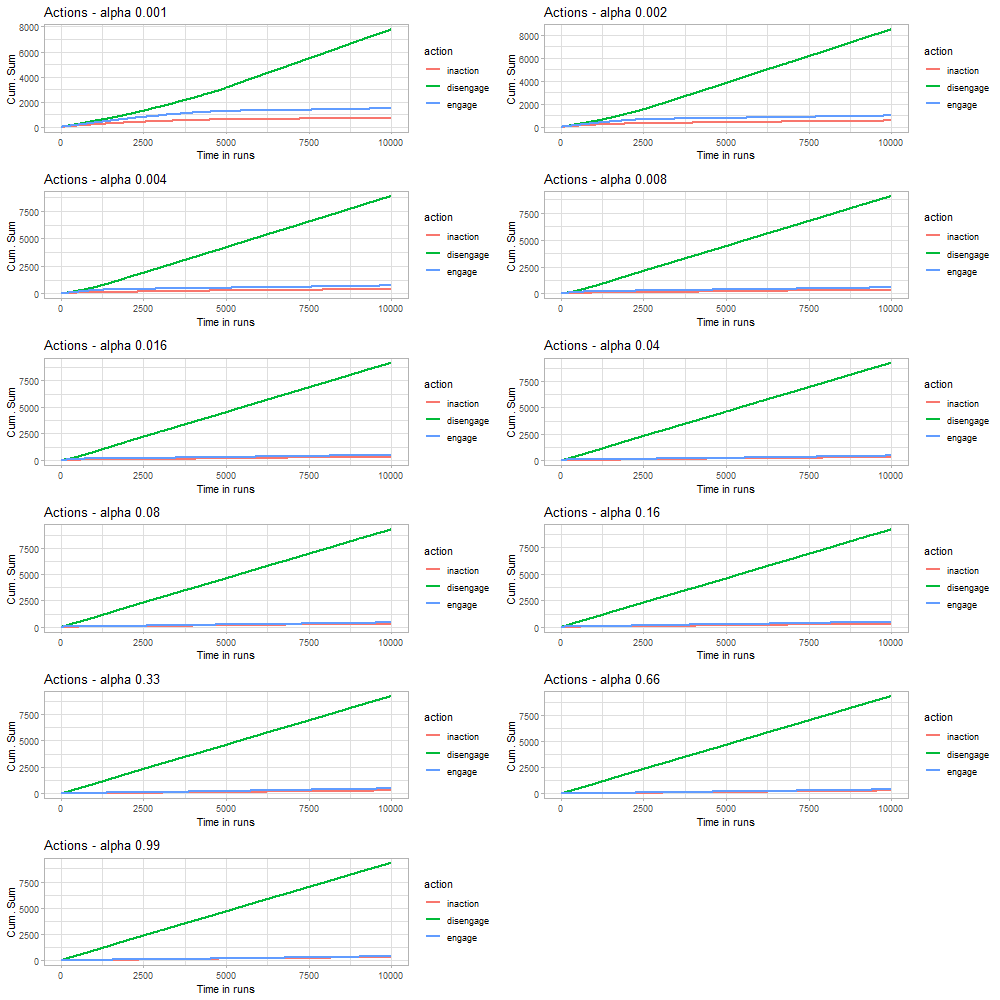

##### Trajectories

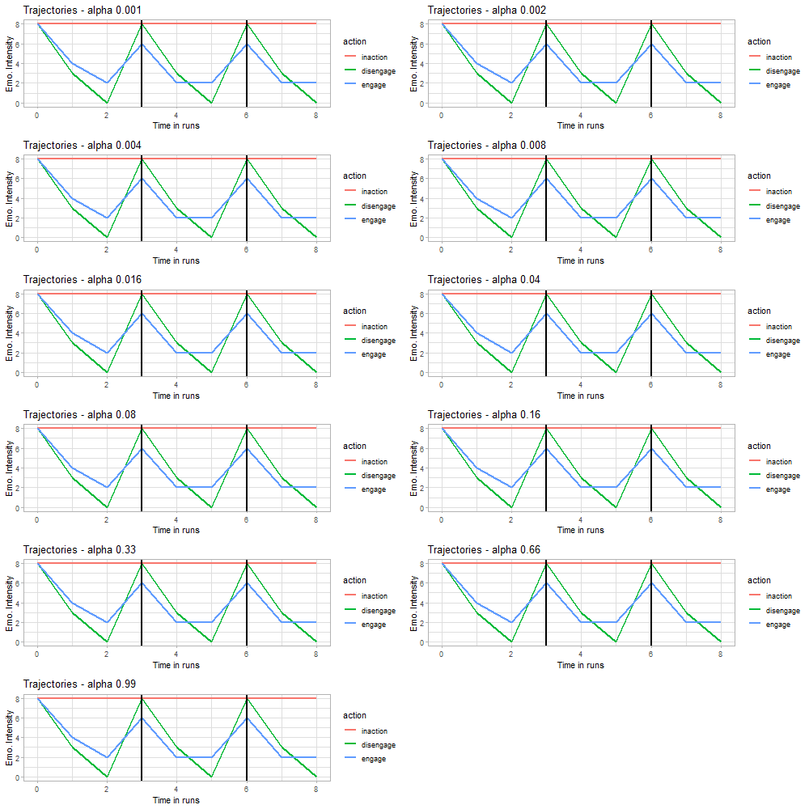

##### Rewards

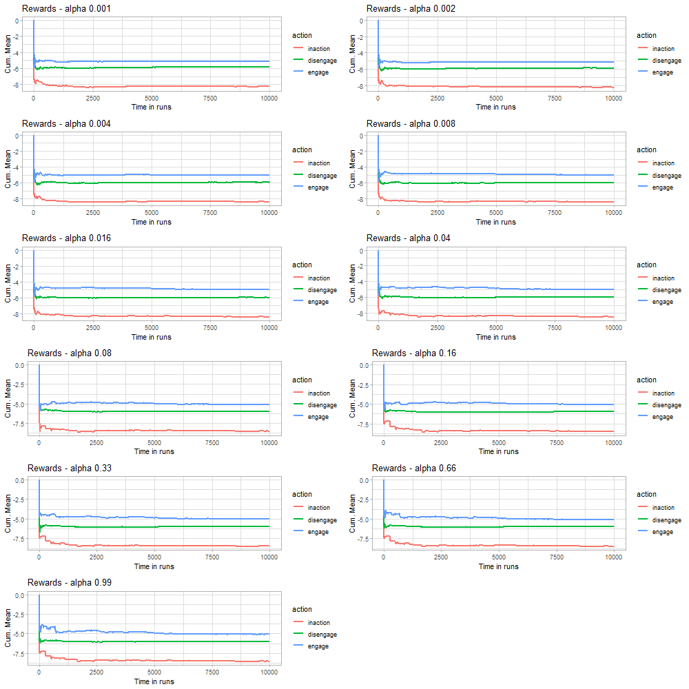

### gamma

This can be used to change how much the agent discounts future rewards. This can be used to model individual differences in long-term vs short-term orientation.

#### Parameter

```r
N_RUNS = 10000
N_STIMULI = 2000
N_ACTIONS = 3

alpha = .001
gamma = [0.99, .98, .96, .92, .85, .75, .65, .5, .35, .2, .1, .01]
epsilon = .1

engage_delay = 2
engage_benefit = 4
disengage_benefit = 5
engage_adaptation = 2
seed = 123
```

#### Plots

##### Actions

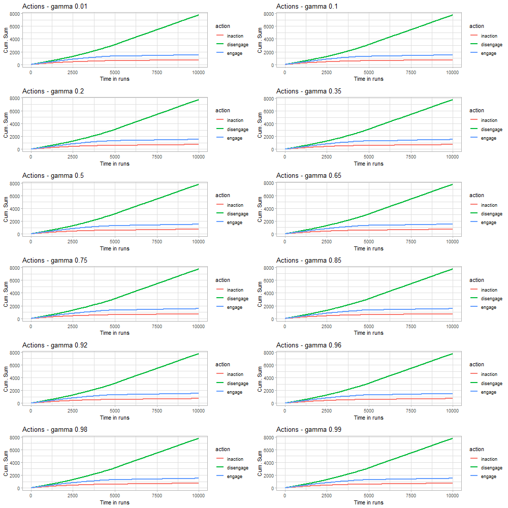

##### Trajectories

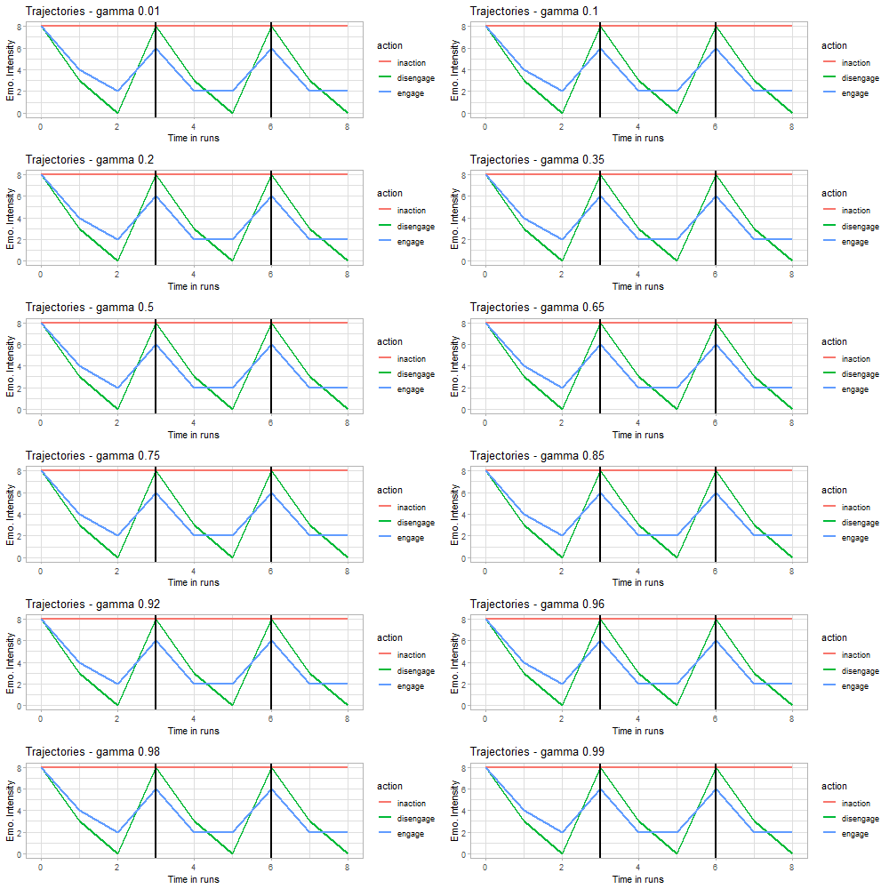

##### Rewards

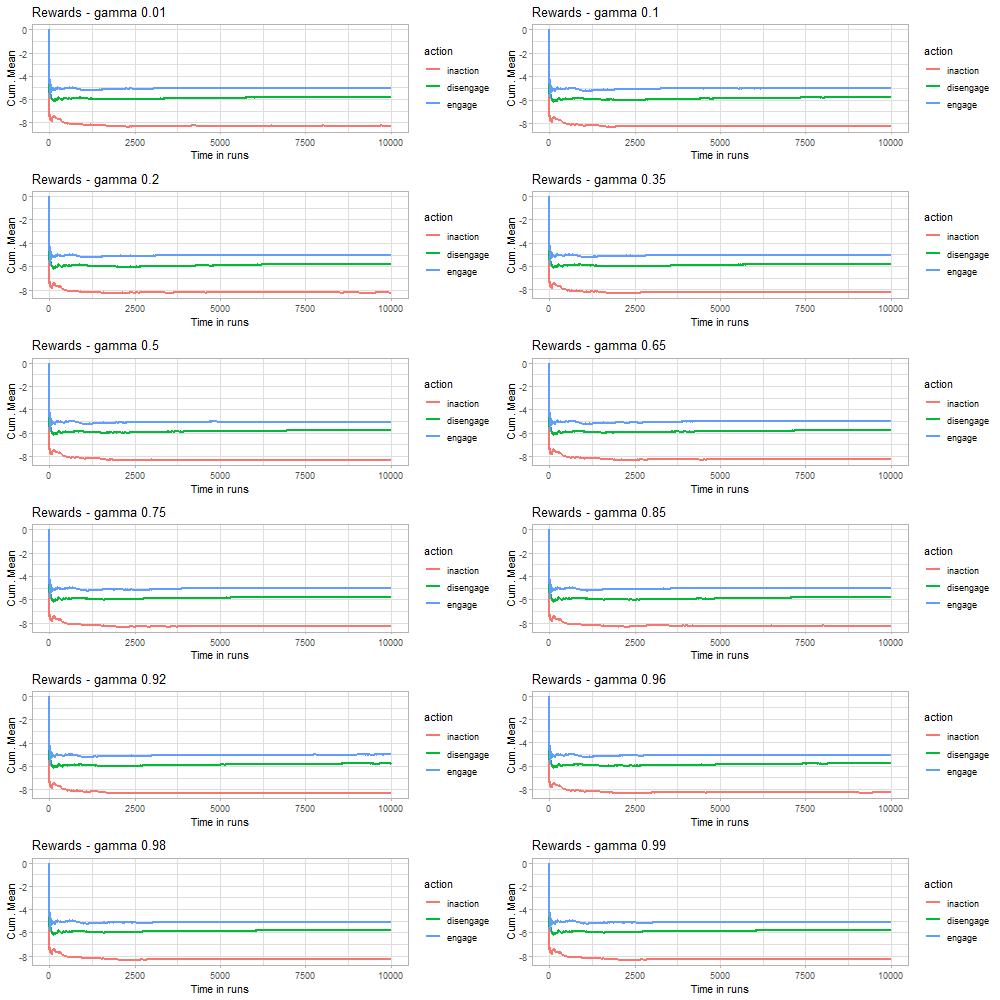

### epsilon

This can be used to change how much the agent explores alternative actions, ignoring what is expected to be the highest reward. This is necessary for the RL model to work, but could also be used to model individual differences in e.g. openess to experience(?).

#### Parameter

```r
N_RUNS = 10000
N_STIMULI = 2000
N_ACTIONS = 3

alpha = .001
gamma = .99
epsilon = [.1, .2, 3., .4, .5, .6, .7, .8, .9, 1]

engage_delay = 2
engage_benefit = 4
disengage_benefit = 5
engage_adaptation = 2
seed = 123
```

#### Plots

##### Actions

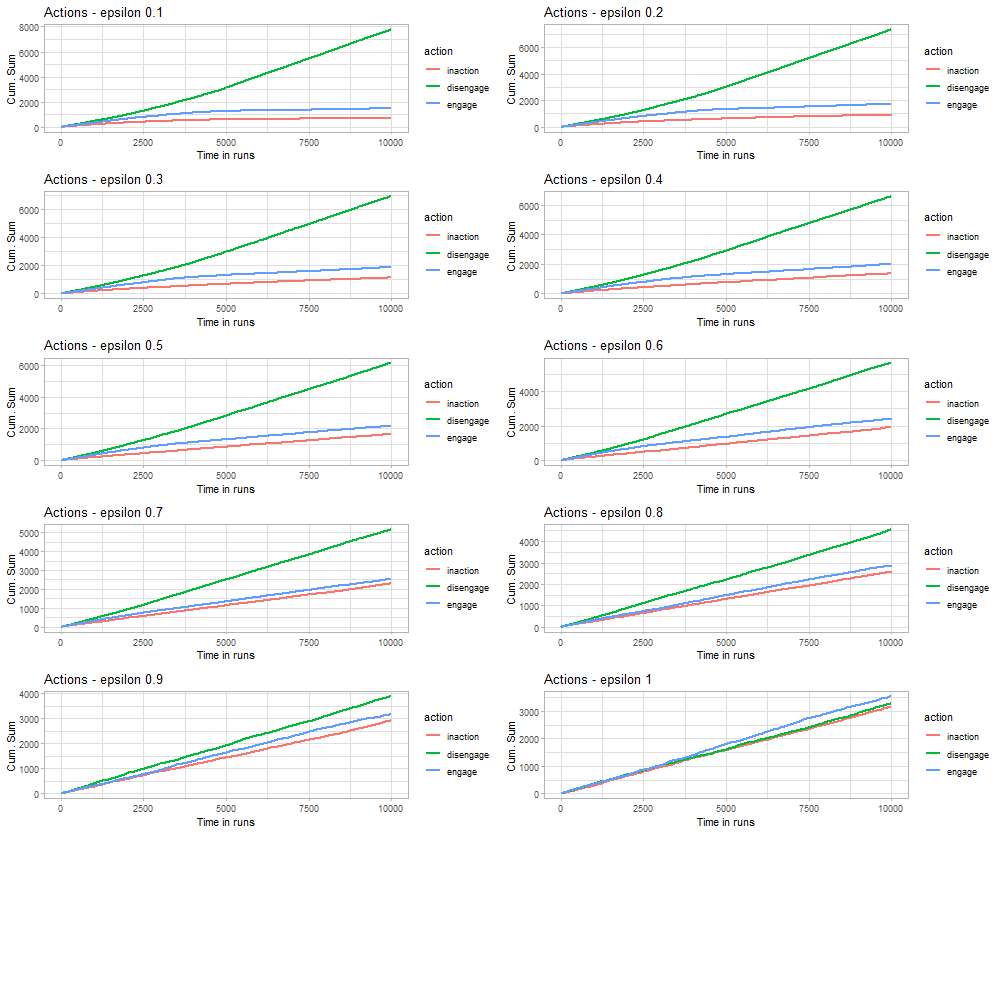

##### Trajectories

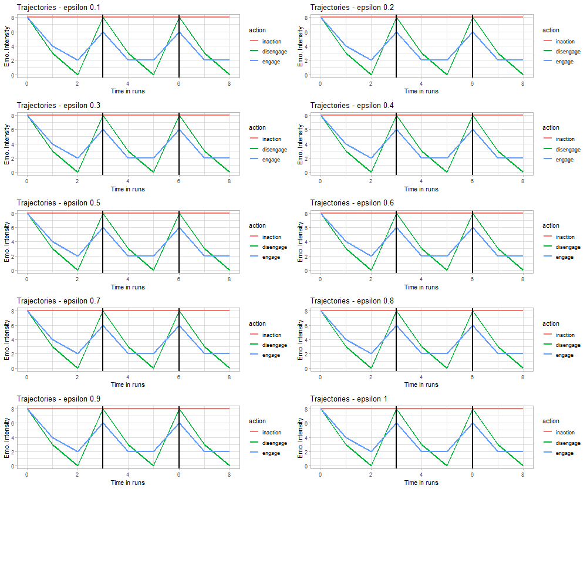

##### Rewards

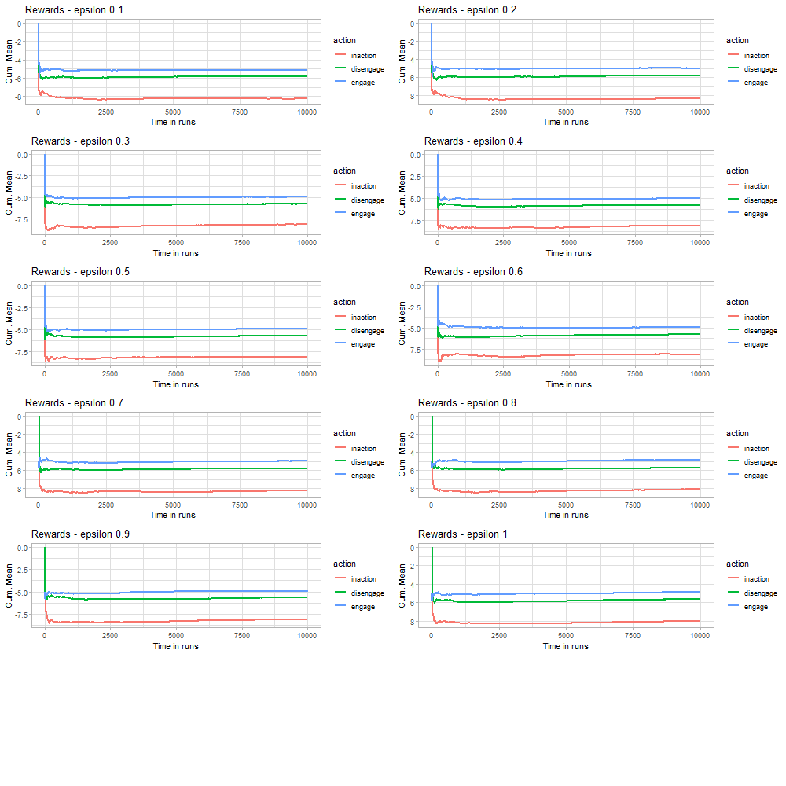

### engage_delay

This determines how long the agent takes to adapt to a stimulus using engagement. Technically, it determines at which time point the `engage_adaptation` gets substracted from the emotional intensity of the stimulus. This could possibly be used to model people that are faster or slower at reppraisal.

#### Parameter

```r
N_RUNS = 10000
N_STIMULI = 2000
N_ACTIONS = 3

alpha = .001
gamma = .99
epsilon = .1

engage_delay = [0, 1, 2]
engage_benefit = 4
disengage_benefit = 5
engage_adaptation = 2
seed = 123
```

#### Plots

##### Actions

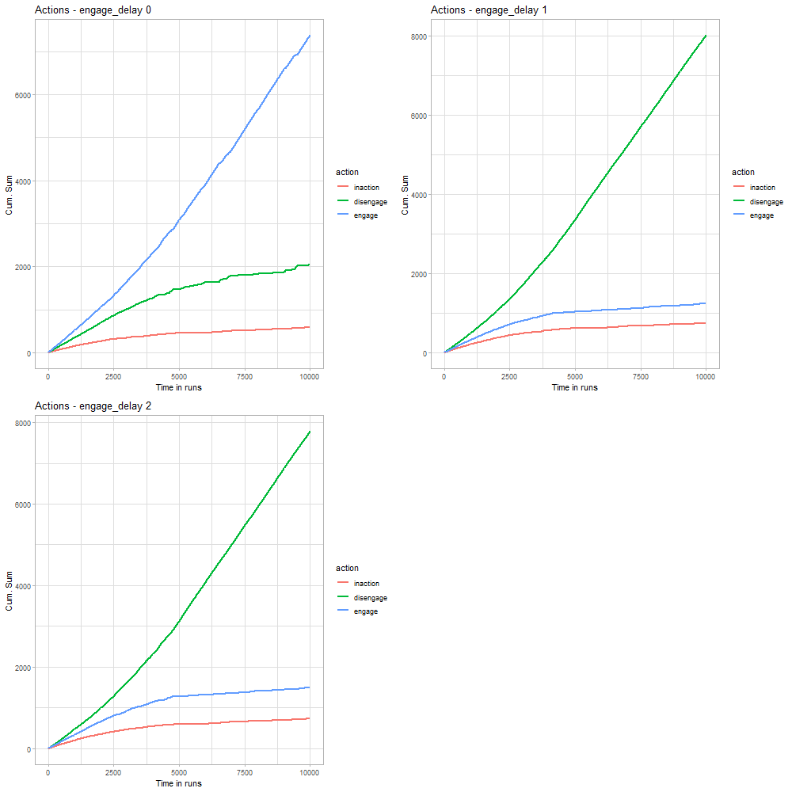

##### Trajectories

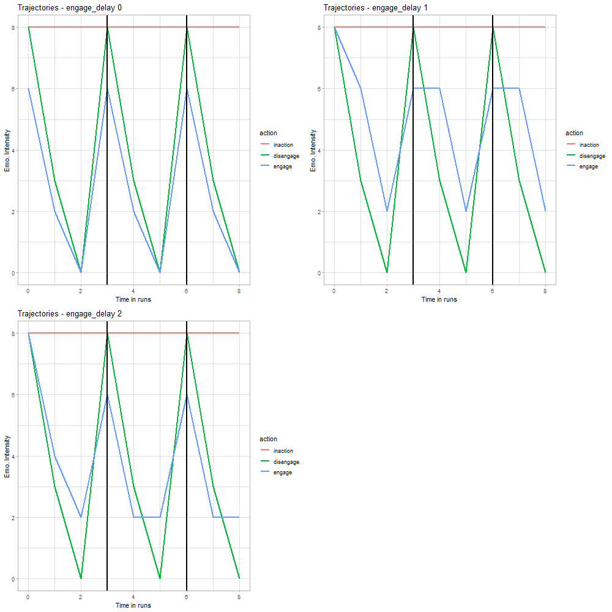

##### Rewards

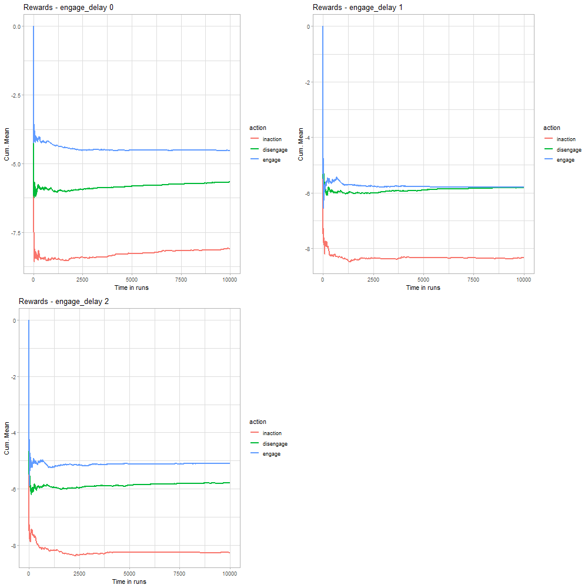

### engage_delay

This determines how long the agent takes to adapt to a stimulus using engagement. Technically, it determines at which time point the `engage_adaptation` gets substracted from the emotional intensity of the stimulus. This could possibly be used to model people that are faster or slower at reppraisal.

#### Parameter

```r
N_RUNS = 10000
N_STIMULI = 2000
N_ACTIONS = 3

alpha = .001
gamma = .99
epsilon = .1

engage_delay = [0, 1, 2]
engage_benefit = 4
disengage_benefit = 5
engage_adaptation = 2
seed = 123
```

#### Plots

##### Actions

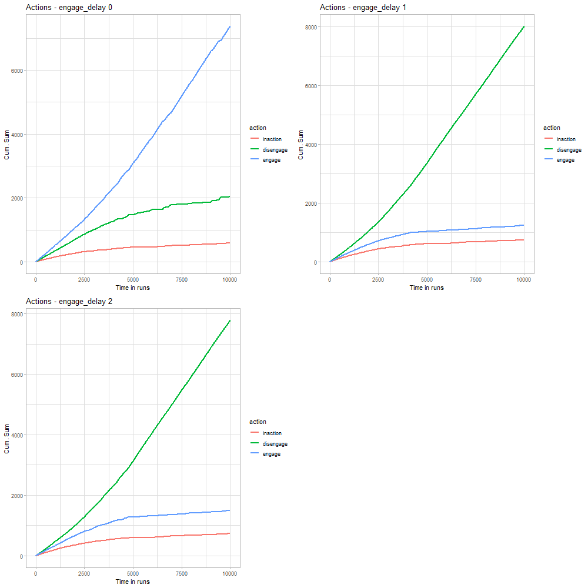

##### Trajectories

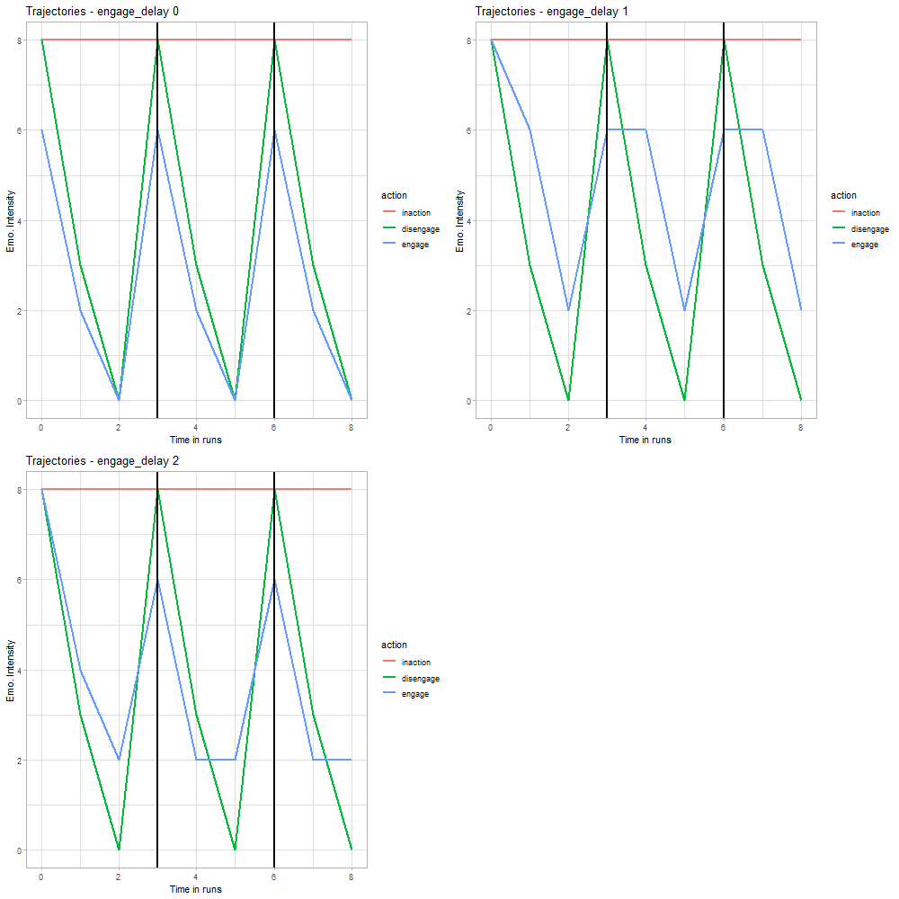

##### Rewards

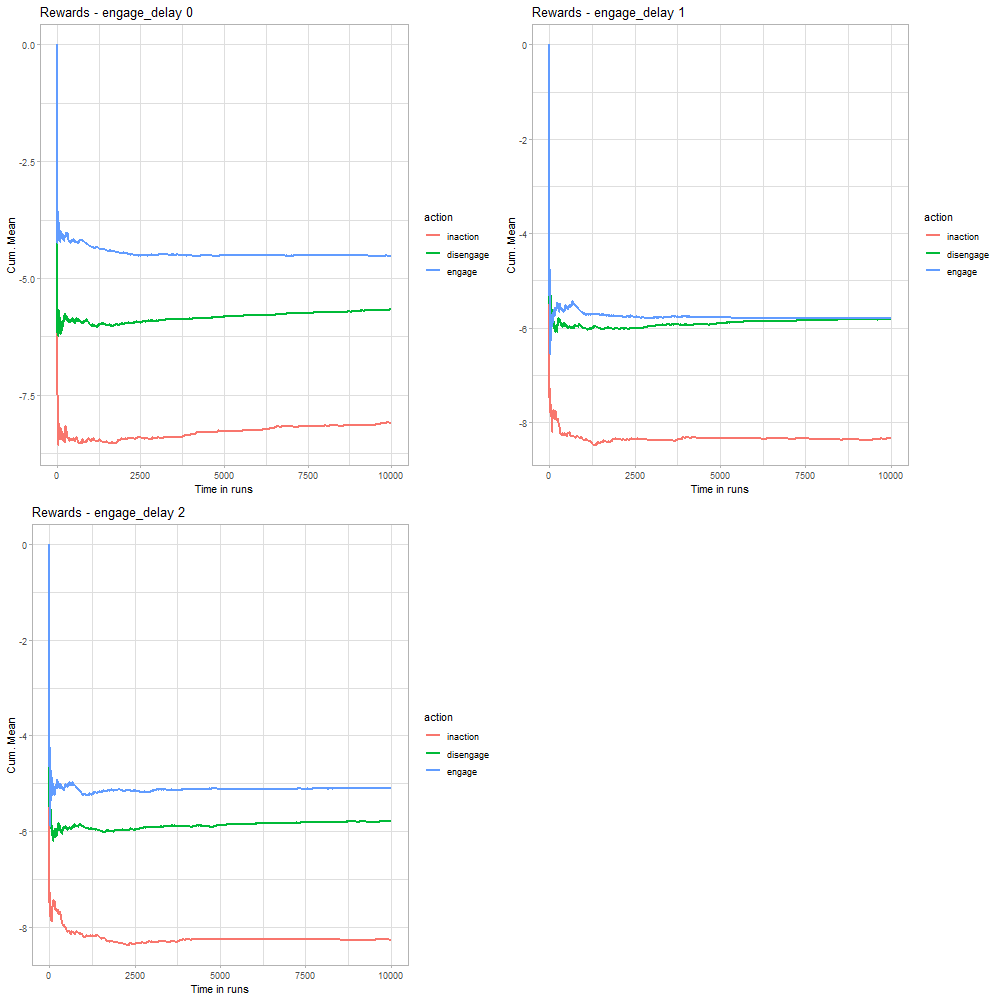

### engage_benefit

This determines how much engagement reduces the emotional intensity immediately. This is different from `engage_adapt`, which determines how much the emotional intensity is reducedd in the long-term. We expect this to be lower than the reduction when using disengagement.

#### Parameter

```r
N_RUNS = 10000
N_STIMULI = 2000
N_ACTIONS = 3

alpha = .001
gamma = .99
epsilon = .1

engage_delay = 2
engage_benefit = 1:10
disengage_benefit = 5
engage_adaptation = 2
seed = 123
```

#### Plots

##### Actions

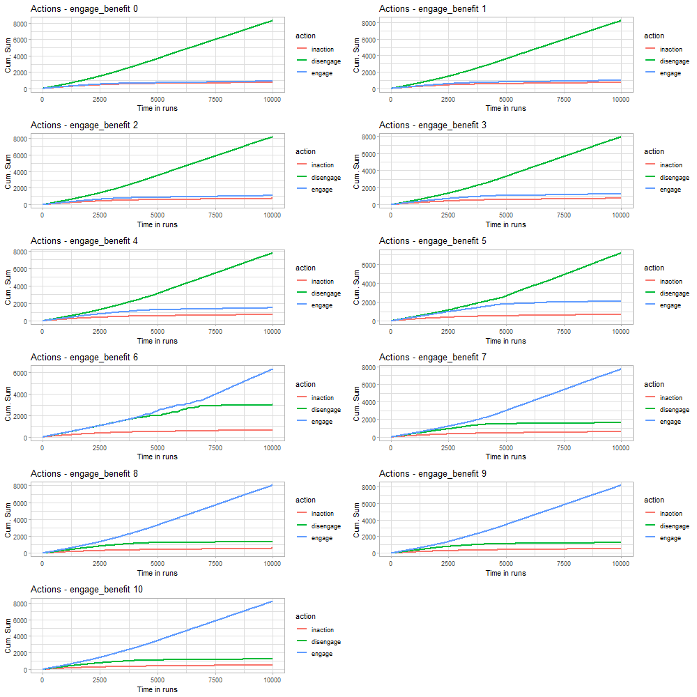

##### Trajectories

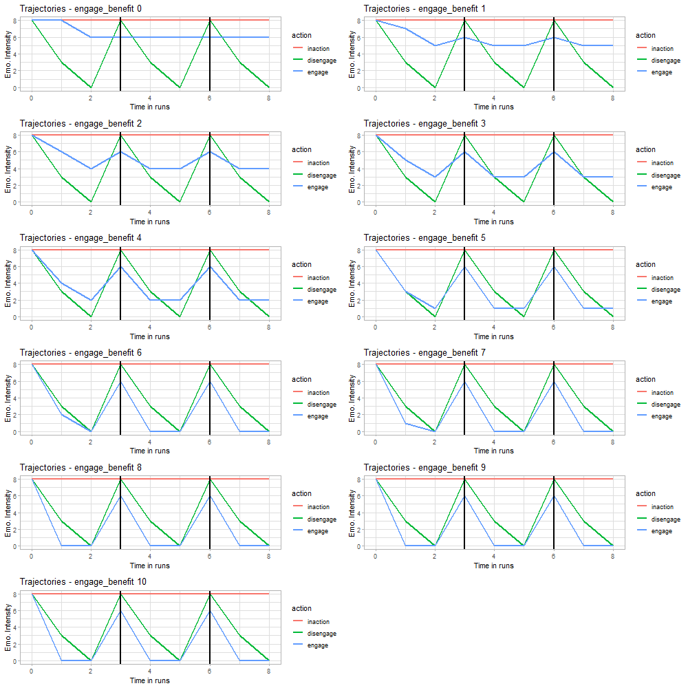

##### Rewards

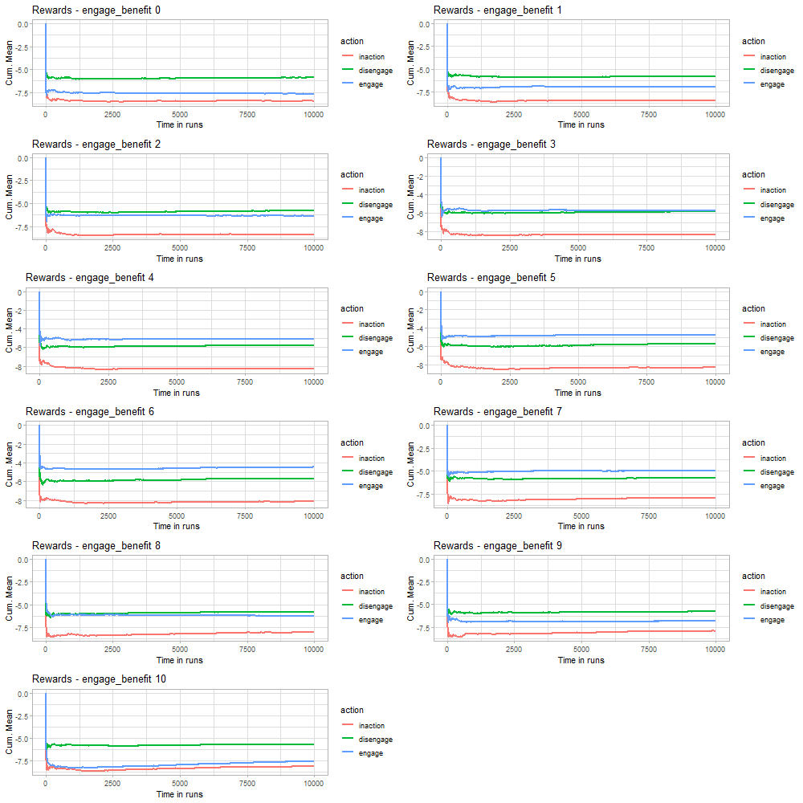

### disengage_benefit

This determines how much disengagement reduces the emotional intensity at every time point it is used.

#### Parameter

```r
N_RUNS = 10000
N_STIMULI = 2000
N_ACTIONS = 3

alpha = .001
gamma = .99
epsilon = .1

engage_delay = 2
engage_benefit = 4
disengage_benefit = 1:10
engage_adaptation = 2
seed = 123
```

#### Plots

##### Actions

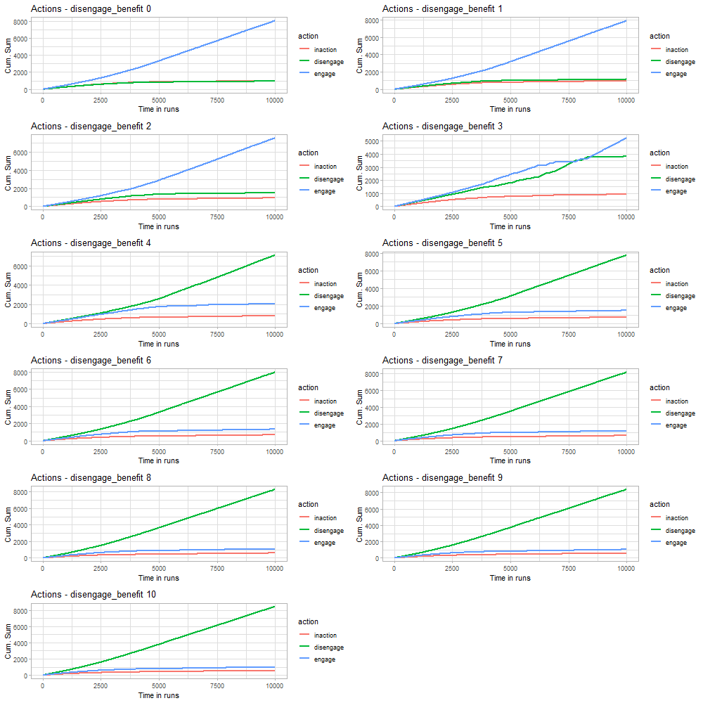

##### Trajectories

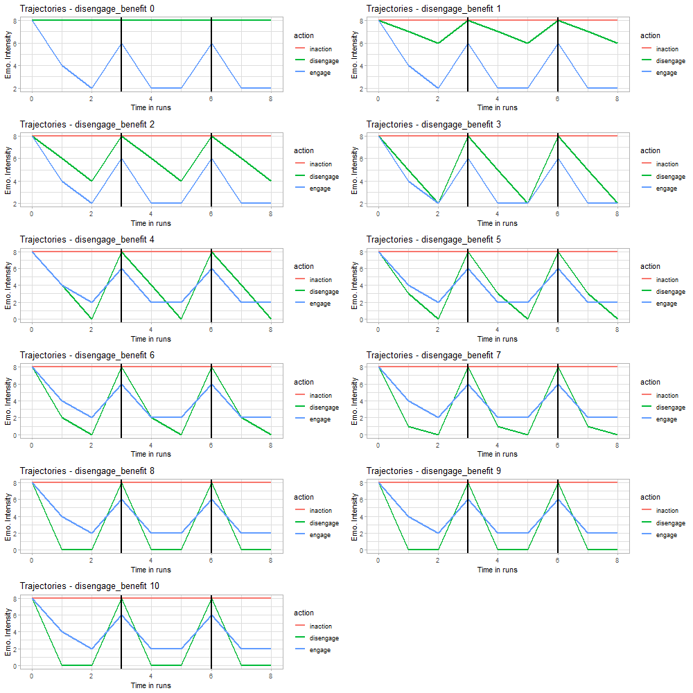

##### Rewards

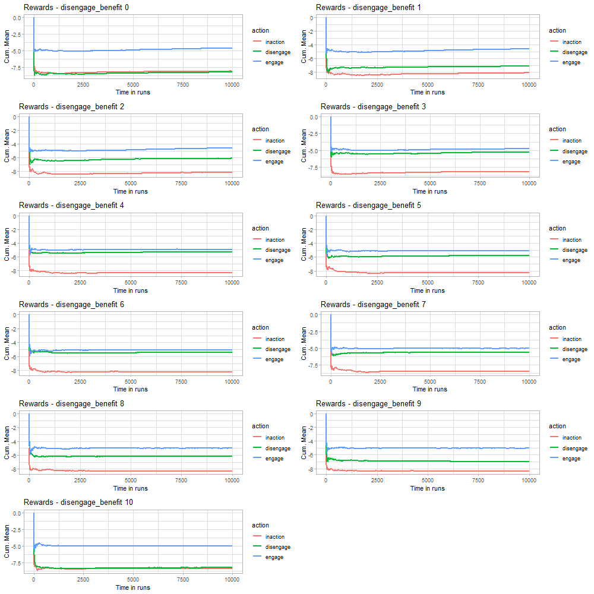

### engage_adaptation

This determines how much engagement changes the emotional intensity in the long-term, at time point `engage_delay` of the first encounter.

#### Parameter

```r
N_RUNS = 10000
N_STIMULI = 2000
N_ACTIONS = 3

alpha = .001
gamma = .99
epsilon = .1

engage_delay = 2
engage_benefit = 4
disengage_benefit = 5
engage_adaptation = 1:10
seed = 123
```

#### Plots

##### Actions

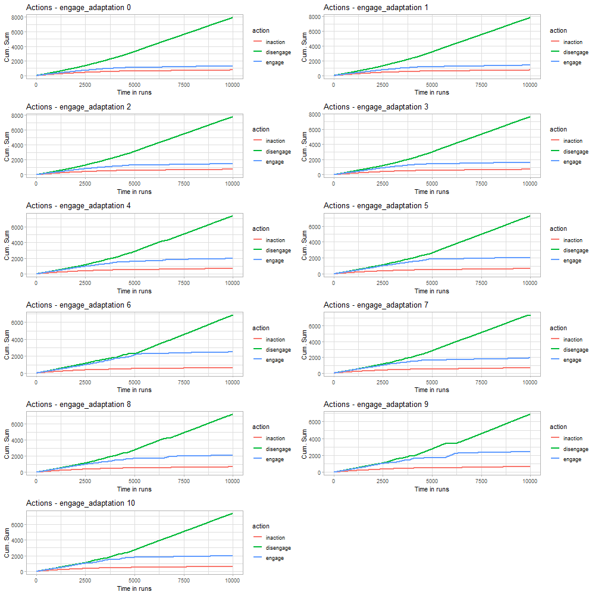

##### Trajectories

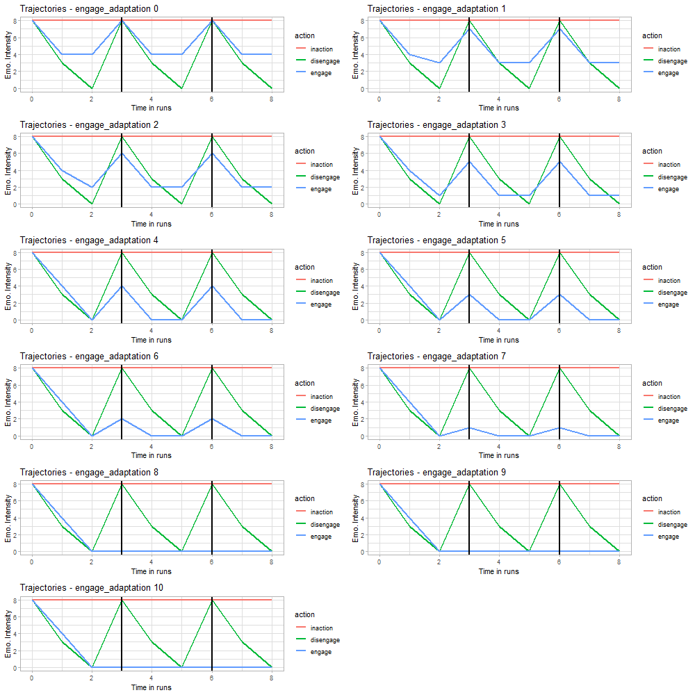

##### Rewards

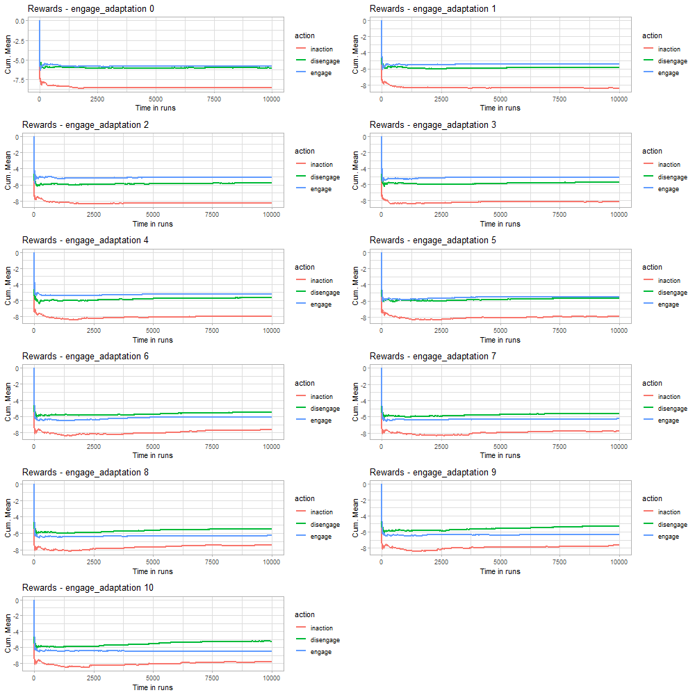